# Antibiotic Resistance in Clinical *Salmonella* (USA, 2015–2025)

Elijah

2026-04-25

# Introduction

Antimicrobial resistance (AMR) in *Salmonella enterica* represents a growing public health threat in the United States. Fluoroquinolones such as ciprofloxacin are among the most critical treatments for severe salmonellosis — resistance to these drugs significantly limits clinical options. This analysis examines resistance trends across five antibiotic classes in 57,297 clinical *Salmonella* isolates collected between 2015 and 2025, with a focus on identifying which serovars are driving observed changes.

**Data source:** NCBI Pathogen Detection Database. Analysis restricted to clinical (human) isolates from US submissions with complete AMR genotype data.

# Data Preparation

```r
df <- read_excel("salmonella_clinical_amr.xlsx")

df <- df |>
  mutate(
    res_betalactam    = str_detect(amr_genotypes, "blaTEM|blaCMY|blaCARB"),
    res_tetracycline  = str_detect(amr_genotypes, "tet\\("),
    res_fluoroquinol  = str_detect(amr_genotypes, "gyrA_|qnr"),
    res_sulfonamide   = str_detect(amr_genotypes, "sul1|sul2"),
    res_chloramphenic = str_detect(amr_genotypes, "floR"),
    resistance_count  = res_betalactam + res_tetracycline + res_fluoroquinol +
                        res_sulfonamide + res_chloramphenic,
    is_MDR = resistance_count >= 3,
    serovar = case_when(
      serovar == "Salmonella Enteritidis" ~ "Enteritidis",
      TRUE ~ serovar
    ),
    state = case_when(
      str_detect(location, "CA$|California|San Diego") ~ "california",
      str_detect(location, "USA:NY|USA: NY|New York")  ~ "new york",
      str_detect(location, "TX$|USA: TX|Texas")         ~ "texas",
      str_detect(location, "USA:WA|USA: WA|Washington") &
        !str_detect(location, "DC")                     ~ "washington",
      str_detect(location, "NE$|Nebraska")              ~ "nebraska",
      str_detect(location, "MN$|USA: MN|Minnesota")     ~ "minnesota",
      str_detect(location, "WI$|USA: WI")               ~ "wisconsin",
      str_detect(location, "PA$|USA: PA")               ~ "pennsylvania",
      str_detect(location, "KY$|USA: KY|Kentucky")      ~ "kentucky",
      str_detect(location, "MI$|USA: MI")               ~ "michigan",
      str_detect(location, "OR$|Oregon")                ~ "oregon",
      str_detect(location, "IA$|USA: IA")               ~ "iowa",
      str_detect(location, "UT$|USA: UT")               ~ "utah",
      str_detect(location, "MA$|Boston")                ~ "massachusetts",
      str_detect(location, "USA:SC")                    ~ "south carolina",
      str_detect(location, "USA:NC")                    ~ "north carolina",
      str_detect(location, "USA:FL")                    ~ "florida",
      str_detect(location, "USA:AZ")                    ~ "arizona",
      str_detect(location, "USA:CO")                    ~ "colorado",
      str_detect(location, "USA:GA")                    ~ "georgia",
      str_detect(location, "USA:WY")                    ~ "wyoming",
      str_detect(location, "USA:OH")                    ~ "ohio",
      str_detect(location, "USA:NM")                    ~ "new mexico",
      str_detect(location, "USA:TN")                    ~ "tennessee",
      str_detect(location, "USA:NH")                    ~ "new hampshire",
      str_detect(location, "USA:CT")                    ~ "connecticut",
      str_detect(location, "USA:HI")                    ~ "hawaii",
      TRUE ~ NA_character_
    )
  )
```

# Results

## Overall Resistance Trends

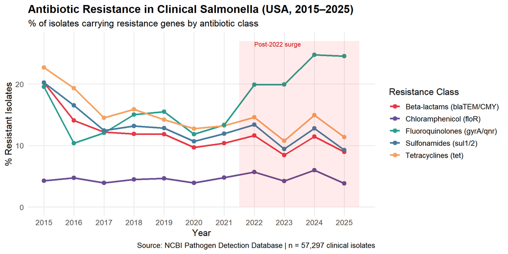

```r
trends <- df |>
  group_by(year) |>
  summarize(
    betalactam    = mean(res_betalactam) * 100,
    tetracycline  = mean(res_tetracycline) * 100,
    fluoroquinol  = mean(res_fluoroquinol) * 100,
    sulfonamide   = mean(res_sulfonamide) * 100,
    chloramphenic = mean(res_chloramphenic) * 100
  )

trends_long <- trends |>
  pivot_longer(cols = -year, names_to = "resistance", values_to = "percent")

ggplot(trends_long, aes(x = year, y = percent, color = resistance)) +
  geom_line(linewidth = 1.2) +
  geom_point(size = 2.5) +
  annotate("rect", xmin = 2021.5, xmax = 2025.5, ymin = 0, ymax = 27,
           alpha = 0.08, fill = "red") +
  annotate("text", x = 2022, y = 26.5, label = "Post-2022 surge",
           size = 3.2, color = "red3", hjust = 0) +
  scale_color_manual(
    values = c(
      "betalactam"    = "#E63946",
      "tetracycline"  = "#F4A261",
      "fluoroquinol"  = "#2A9D8F",
      "sulfonamide"   = "#457B9D",
      "chloramphenic" = "#6A4C93"
    ),
    labels = c(
      "betalactam"    = "Beta-lactams (blaTEM/CMY)",
      "tetracycline"  = "Tetracyclines (tet)",
      "fluoroquinol"  = "Fluoroquinolones (gyrA/qnr)",
      "sulfonamide"   = "Sulfonamides (sul1/2)",
      "chloramphenic" = "Chloramphenicol (floR)"
    )
  ) +
  scale_x_continuous(breaks = 2015:2025) +
  labs(
    title = "Antibiotic Resistance in Clinical Salmonella (USA, 2015–2025)",
    subtitle = "% of isolates carrying resistance genes by antibiotic class",
    x = "Year", y = "% Resistant Isolates", color = "Resistance Class",
    caption = "Source: NCBI Pathogen Detection Database | n = 57,297 clinical isolates"
  ) +
  theme_minimal(base_size = 13) +
  theme(plot.title = element_text(face = "bold"),
        panel.grid.minor = element_blank())
```

## Multidrug Resistance

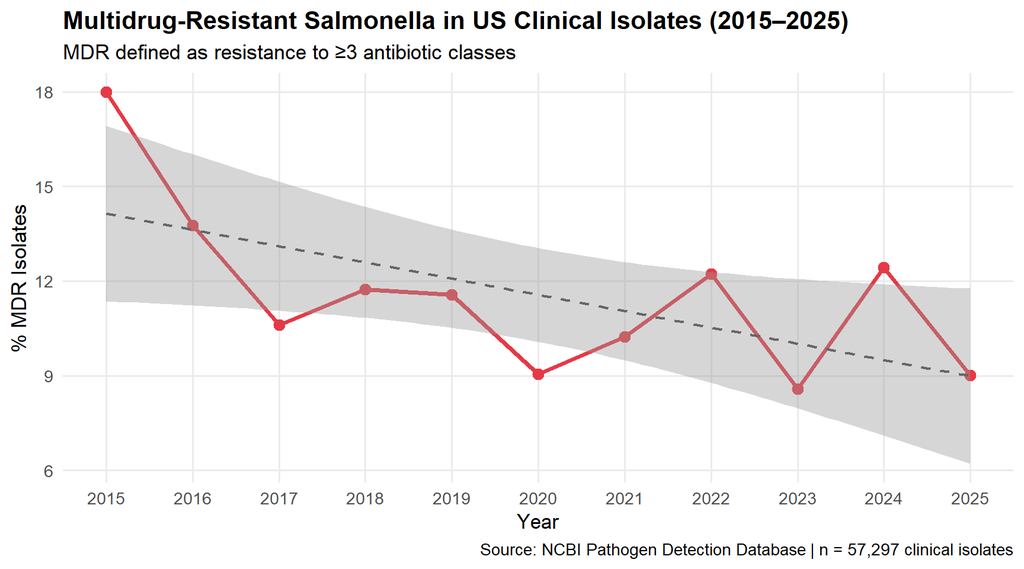

```r
mdr_trends <- df |>
  group_by(year) |>
  summarize(pct_MDR = mean(is_MDR) * 100, n = n())

ggplot(mdr_trends, aes(x = year, y = pct_MDR)) +
  geom_line(linewidth = 1.3, color = "#E63946") +
  geom_point(size = 3, color = "#E63946") +
  geom_smooth(method = "lm", se = TRUE, linetype = "dashed",
              color = "gray40", linewidth = 0.8) +
  scale_x_continuous(breaks = 2015:2025) +
  labs(
    title = "Multidrug-Resistant Salmonella in US Clinical Isolates (2015–2025)",
    subtitle = "MDR defined as resistance to ≥3 antibiotic classes",
    x = "Year", y = "% MDR Isolates",
    caption = "Source: NCBI Pathogen Detection Database | n = 57,297 clinical isolates"
  ) +
  theme_minimal(base_size = 13) +
  theme(plot.title = element_text(face = "bold"),
        panel.grid.minor = element_blank())
```

## Geographic Distribution

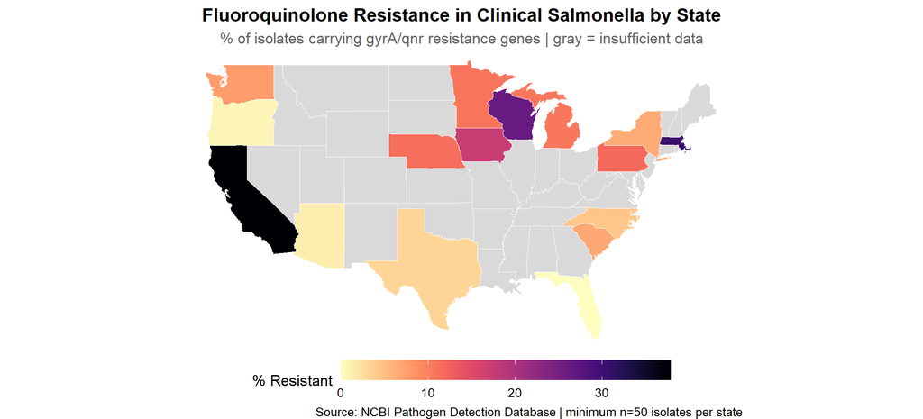

```r
state_resistance <- df |>
  filter(!is.na(state)) |>
  group_by(state) |>
  summarize(
    pct_fluoroquinol = mean(res_fluoroquinol) * 100,
    pct_MDR          = mean(is_MDR) * 100,
    n                = n()
  ) |>
  filter(n >= 50)

us_map <- map_data("state")
map_df  <- us_map |>
  left_join(state_resistance, by = c("region" = "state"))

ggplot(map_df, aes(x = long, y = lat, group = group, fill = pct_fluoroquinol)) +
  geom_polygon(color = "white", linewidth = 0.3) +
  coord_fixed(1.3) +
  scale_fill_viridis(option = "magma", direction = -1,
                     na.value = "gray85", name = "% Resistant") +
  labs(
    title = "Fluoroquinolone Resistance in Clinical Salmonella by State",
    subtitle = "% of isolates carrying gyrA/qnr resistance genes | gray = insufficient data",
    caption = "Source: NCBI Pathogen Detection Database | minimum n=50 isolates per state"
  ) +
  theme_void(base_size = 13) +
  theme(plot.title    = element_text(face = "bold", hjust = 0.5),
        plot.subtitle = element_text(hjust = 0.5, color = "gray40"),
        legend.position = "bottom",
        legend.key.width = unit(2, "cm"))
```

California showed notably elevated fluoroquinolone resistance relative to other states. This likely reflects a combination of population density, high international travel volume, and intensive agricultural antibiotic use in the Central Valley. It should be noted that geographic coverage is uneven — most states are gray due to insufficient NCBI submissions, reflecting lab participation patterns rather than true absence of resistance.

## Serovar Breakdown

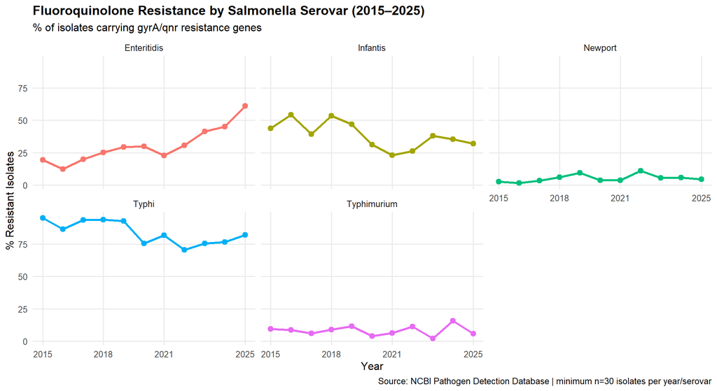

```r
serovar_trends <- df |>
  filter(serovar %in% c("Enteritidis", "Typhimurium", "Newport",
                         "Infantis", "Typhi")) |>
  group_by(year, serovar) |>
  summarize(
    pct_fluoroquinol = mean(res_fluoroquinol) * 100,
    n = n(), .groups = "drop"
  ) |>
  filter(n >= 30)

ggplot(serovar_trends, aes(x = year, y = pct_fluoroquinol, color = serovar)) +
  geom_line(linewidth = 1.2) +
  geom_point(size = 2.5) +
  facet_wrap(~ serovar, ncol = 3, scales = "fixed") +
  scale_x_continuous(breaks = c(2015, 2018, 2021, 2025)) +
  labs(
    title = "Fluoroquinolone Resistance by Salmonella Serovar (2015–2025)",
    subtitle = "% of isolates carrying gyrA/qnr resistance genes",
    x = "Year", y = "% Resistant Isolates",
    caption = "Source: NCBI Pathogen Detection Database | minimum n=30 isolates per year/serovar"
  ) +
  theme_minimal(base_size = 12) +
  theme(plot.title = element_text(face = "bold"),
        panel.grid.minor = element_blank(),
        legend.position = "none")
```

## Resistance Projection: *S.* Enteritidis to 2030

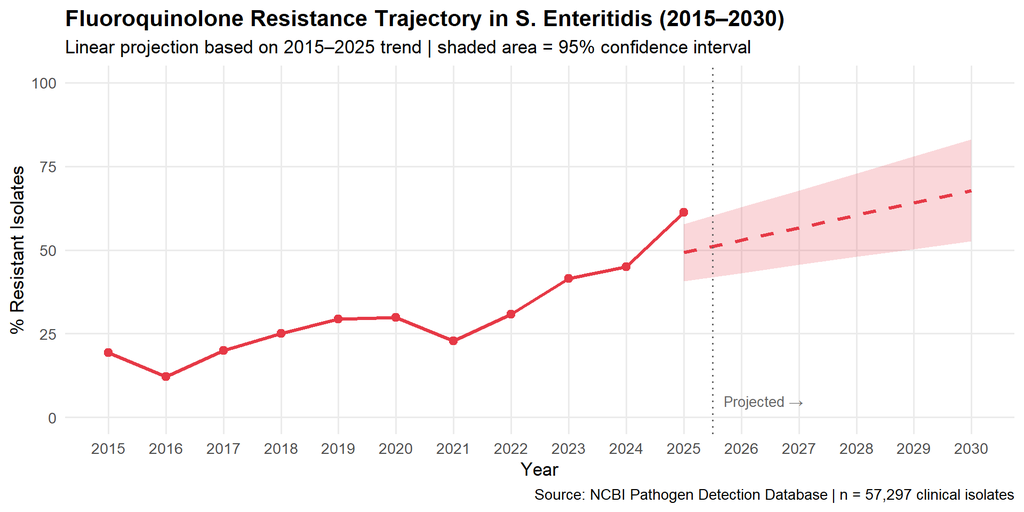

```r
enteritidis_trend <- serovar_trends |>
  filter(serovar == "Enteritidis")

model <- lm(pct_fluoroquinol ~ year, data = enteritidis_trend)

future_years  <- data.frame(year = 2025:2030)
predictions   <- predict(model, newdata = future_years,
                          interval = "confidence") |>
  as.data.frame() |>
  bind_cols(future_years)

ggplot() +
  geom_ribbon(data = predictions,
              aes(x = year, ymin = lwr, ymax = upr),
              alpha = 0.2, fill = "#E63946") +
  geom_line(data = enteritidis_trend,
            aes(x = year, y = pct_fluoroquinol),
            linewidth = 1.2, color = "#E63946") +
  geom_point(data = enteritidis_trend,
             aes(x = year, y = pct_fluoroquinol),
             size = 2.5, color = "#E63946") +
  geom_line(data = predictions,
            aes(x = year, y = fit),
            linewidth = 1.2, linetype = "dashed", color = "#E63946") +
  geom_vline(xintercept = 2025.5, linetype = "dotted", color = "gray40") +
  annotate("text", x = 2025.7, y = 5, label = "Projected →",
           color = "gray40", size = 3.5, hjust = 0) +
  scale_x_continuous(breaks = 2015:2030) +
  scale_y_continuous(limits = c(0, 100)) +
  labs(
    title = "Fluoroquinolone Resistance Trajectory in S. Enteritidis (2015–2030)",
    subtitle = "Linear projection based on 2015–2025 trend | shaded area = 95% confidence interval",
    x = "Year", y = "% Resistant Isolates",
    caption = "Source: NCBI Pathogen Detection Database | n = 57,297 clinical isolates"
  ) +
  theme_minimal(base_size = 13) +
  theme(plot.title = element_text(face = "bold"),
        panel.grid.minor = element_blank())
```

A linear model fit to the 2015–2025 *S.* Enteritidis trend (R² = 0.77) projects resistance reaching approximately 65–70% by 2030 if current trends continue. This projection assumes no major policy interventions, changes in antibiotic prescribing, or surveillance methodology shifts. The observed dip in 2020–2021 likely reflects COVID-19 disruptions to both prescribing patterns and surveillance submissions rather than genuine resistance decline.

# Discussion

This analysis identifies fluoroquinolone resistance in *S.* Enteritidis as the most pressing trend in US clinical *Salmonella* surveillance over the past decade. Several limitations warrant consideration:

- **Geographic bias:** NCBI submission patterns are uneven; states with more represented data likely reflect lab infrastructure rather than true epidemiological differences
- **Genotypic vs. phenotypic resistance:** AMR genotypes predict but do not confirm phenotypic resistance — some genes may be non-expressed
- **Sample representativeness:** This analysis uses a 10% random sample of available isolates; full dataset analysis may refine estimates
- **Linear projection caveats:** Resistance trajectories are rarely linear indefinitely; projections should be interpreted as scenarios rather than forecasts